# Uygulama - Zaman Serileri Analizi: Temel Kavramlar

Finansal Ekonometri (MPİ-TYL)

Prof. Dr. Hüseyin Taştan

Yıldız Teknik Üniversitesi

# 1 Zaman Serisi Grafikleri

```r
library(tidyverse)
library(forecast)
```

## 1.1 Zamana göre çizgi grafiği

### 1.1.1 Örnek: Gayrisafi Yurtiçi Hasıla ve İnşaat Sektörü

```r
load("Data/gsyih_sa_endeks.RData")
tail(gsyih_sa_endeks)
```

```
## # A tibble: 6 × 5
##    year quarter gsyih_sa insaat gmenkul
##   <int> <chr>      <dbl>  <dbl>   <dbl>
## 1  2019 2           176.   204.    135.
## 2  2019 3           177.   203.    136.
## 3  2019 4           180.   201.    140.
## 4  2020 1           180.   206.    140.
## 5  2020 2           161.   202.    138.
## 6  2020 3           186.   213.    140.
```

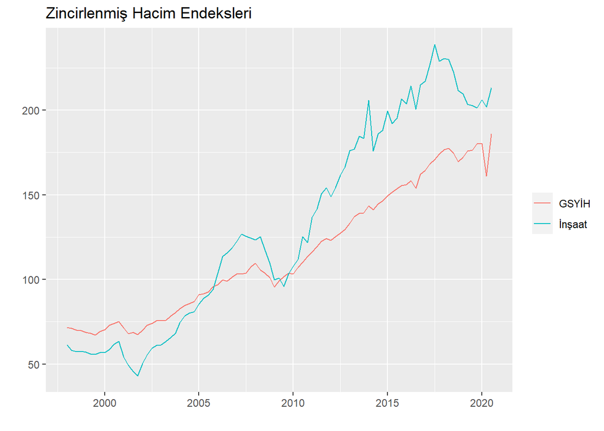

```r
# ts objeleri oluştur
# GSYİH
gsyih_sa_ts <- ts(gsyih_sa_endeks$gsyih_sa, start = c(1998,1), frequency = 4)
# inşaat sektörü GSYİH
insaat_ts <- ts(gsyih_sa_endeks$insaat, start = c(1998,1), frequency = 4)
gmenkul_ts <- ts(gsyih_sa_endeks$gmenkul, start = c(1998,1), frequency = 4)
# zaman serisi grafiği
autoplot(gsyih_sa_ts, series = "GSYİH")+
  autolayer(insaat_ts, series="İnşaat") +
  xlab("") + ylab("") +
  ggtitle("Zincirlenmiş Hacim Endeksleri") +
  theme(legend.title = element_blank()) +
  theme(legend.position = "right")
```

Dönemden döneme büyüme oranları:

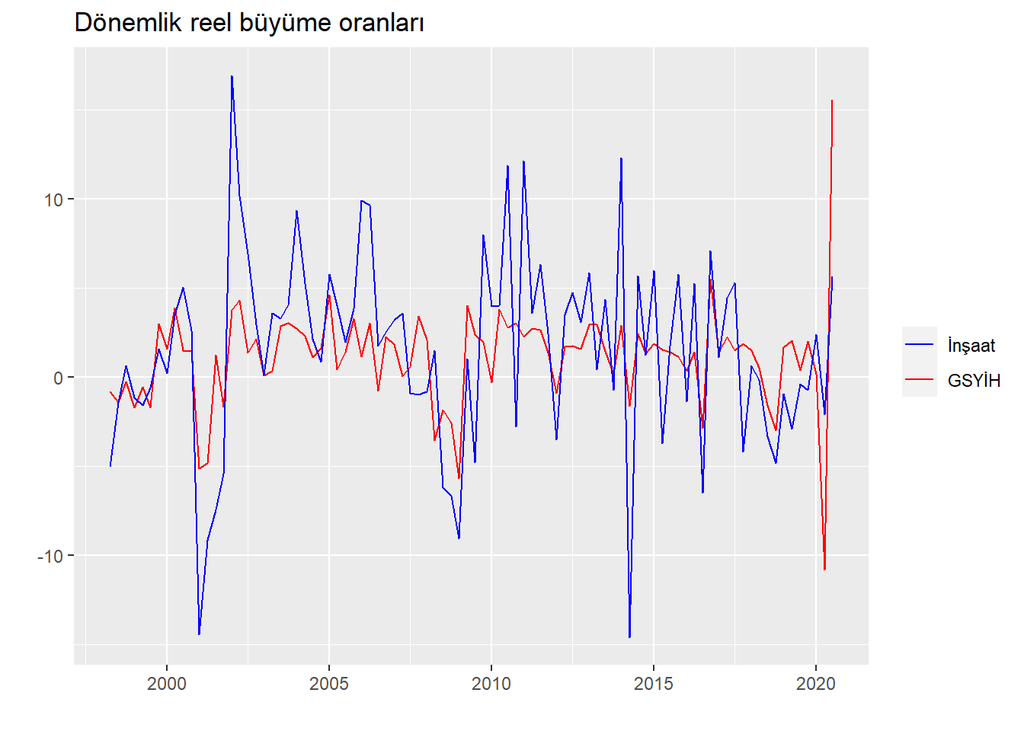

```r
# inşaat sektörü büyüme oranı
insaat_buyume <- 100*(insaat_ts - stats::lag(insaat_ts, -1))/stats::lag(insaat_ts, -1)
# GSYİH dönemlik büyüme oranı
gsyih_buyume <- 100*( gsyih_sa_ts - stats::lag(gsyih_sa_ts, -1))/stats::lag(gsyih_sa_ts, -1)
# dönemlik büyümeler birlikte
autoplot(gsyih_buyume, series = "GSYİH")+
  autolayer(insaat_buyume, series="İnşaat") +
  xlab("") + ylab("") +
  scale_colour_manual(values=c("blue","red" ),
                      breaks=c("İnşaat","GSYİH" )) +
  ggtitle("Dönemlik reel büyüme oranları") +
  theme(legend.title = element_blank())
```

Bir önceki yılın aynı çeyreğine göre büyüme oranları

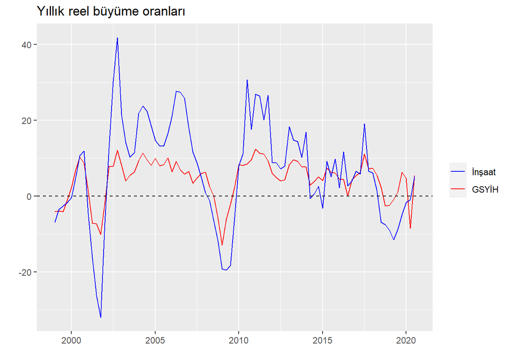

```r
# inşaat sektörü büyüme oranı
insaat_buyume2 <- 100*(insaat_ts - stats::lag(insaat_ts, -4))/stats::lag(insaat_ts, -4)
# GSYİH dönemlik büyüme oranı
gsyih_buyume2 <- 100*( gsyih_sa_ts - stats::lag(gsyih_sa_ts, -4))/stats::lag(gsyih_sa_ts, -4)
# dönemlik büyümeler birlikte
autoplot(gsyih_buyume2, series = "GSYİH")+
  autolayer(insaat_buyume2, series="İnşaat") +
  xlab("") + ylab("") +
  scale_colour_manual(values=c("blue","red" ),
                      breaks=c("İnşaat","GSYİH" )) +
  geom_hline(yintercept = 0, linetype = 2) +
  ggtitle("Yıllık reel büyüme oranları") +
  theme(legend.title = element_blank())
```

## 1.2 Mevsimsel Grafik

### 1.2.1 Örnek: Türkiye’ye gelen turist sayısı

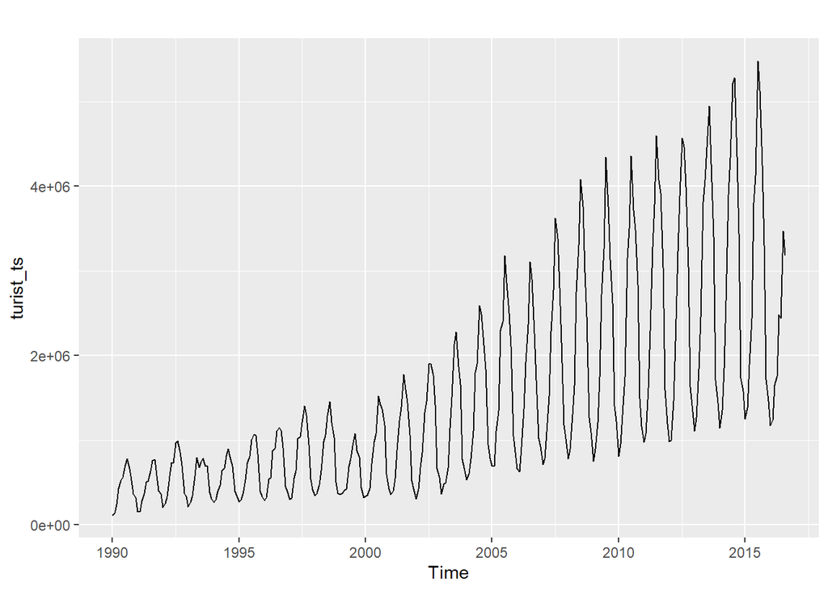

```r
load("Data/turist.rda")
turist_ts <- ts(turist$touristnumber, start = c(1990,1), frequency = 12)
autoplot(turist_ts)
```

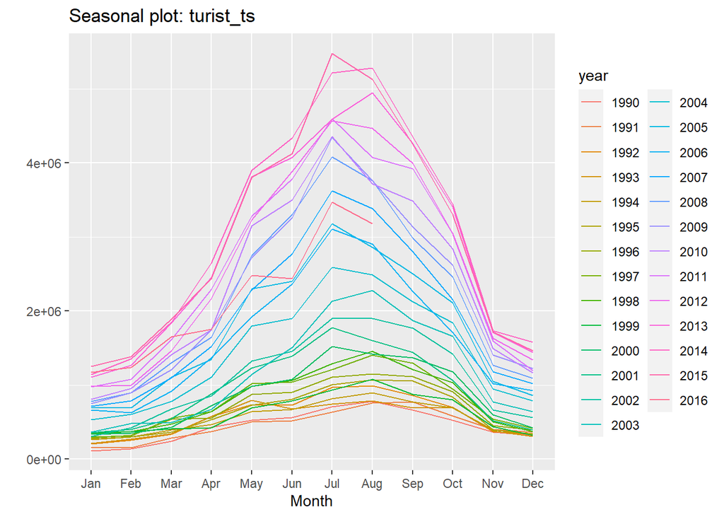

```r
# mevsimsel grafik
forecast::ggseasonplot(turist_ts)
```

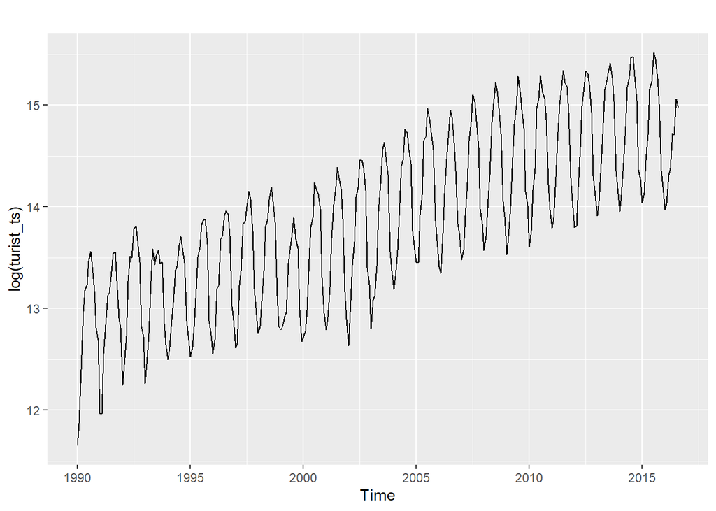

```r
autoplot(log(turist_ts))
```

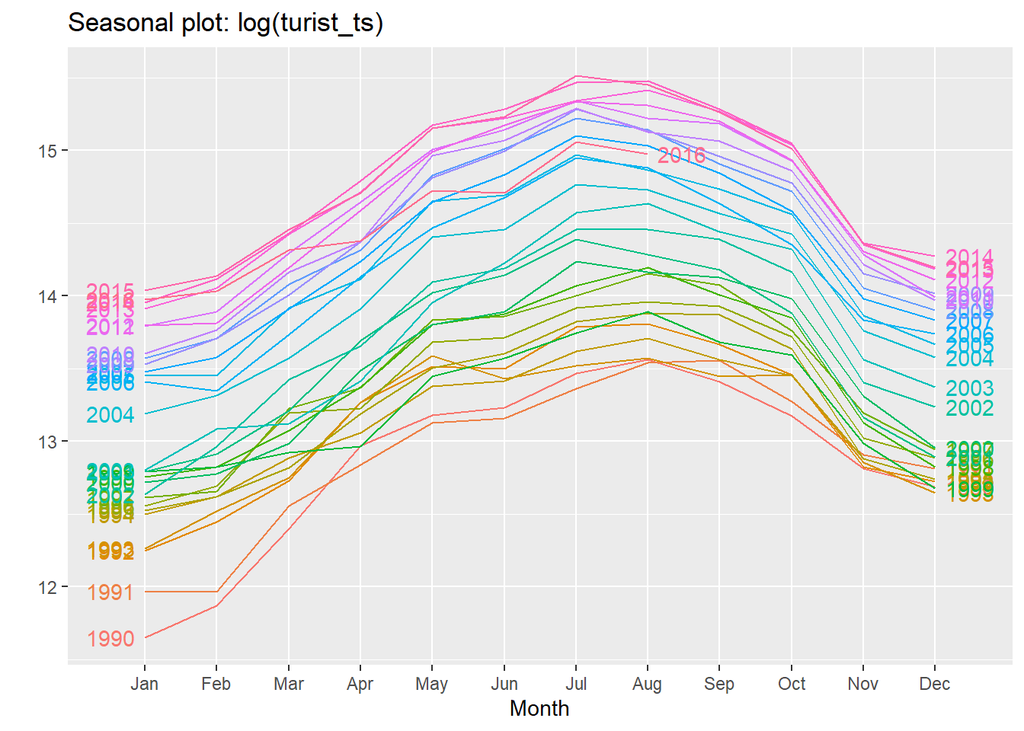

```r
# mevsimsel grafik
forecast::ggseasonplot(log(turist_ts), year.labels=TRUE, year.labels.left=TRUE)
```

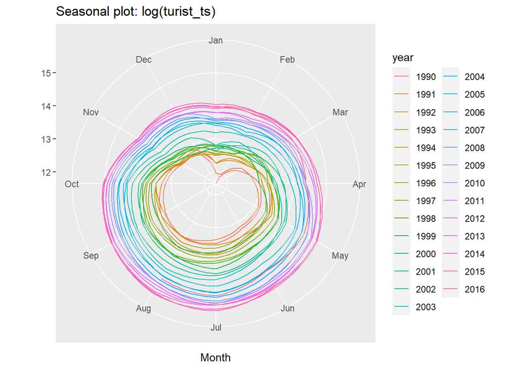

```r
# polar mevsimsel grafik
forecast::ggseasonplot(log(turist_ts), polar=TRUE)
```

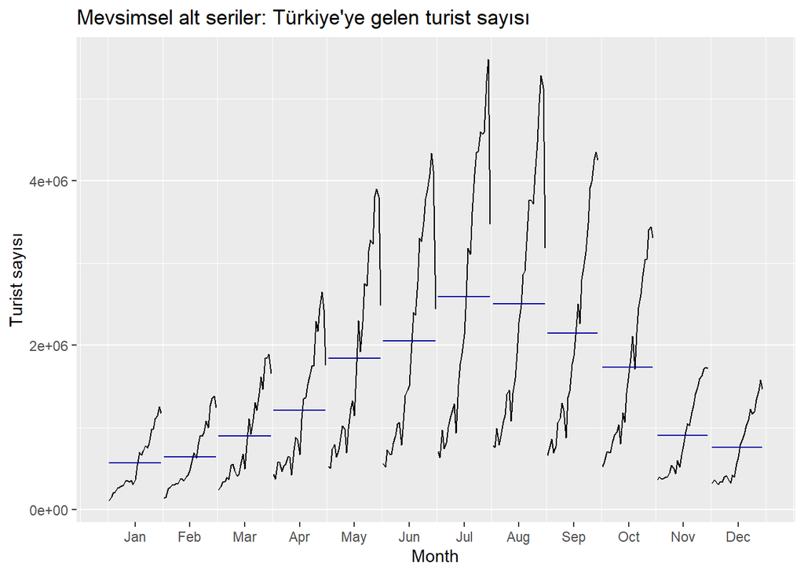

```r
# mevsimsel alt dönemler
ggsubseriesplot(turist_ts) +
  ylab("Turist sayısı") +
  ggtitle("Mevsimsel alt seriler: Türkiye'ye gelen turist sayısı")
```

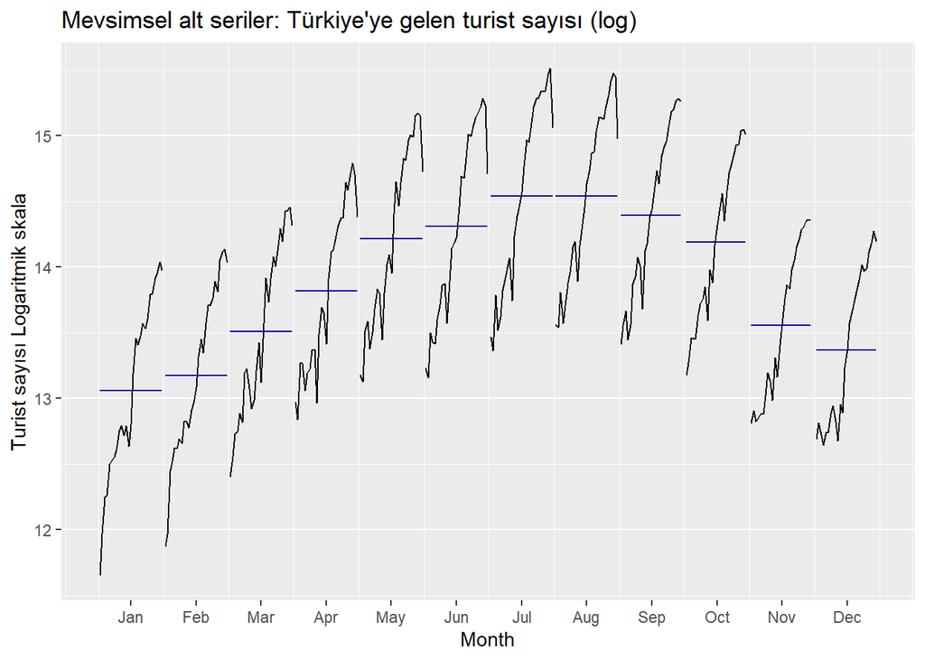

```r
# mevsimsel alt dönemler, logaritmik skala
ggsubseriesplot(log(turist_ts)) +
  ylab("Turist sayısı Logaritmik skala") +
  ggtitle("Mevsimsel alt seriler: Türkiye'ye gelen turist sayısı (log)")
```

## 1.3 Otokorelasyon grafikleri (korelogram)

### 1.3.1 Örnek: İstanbul’da ortalama sıcaklıklar

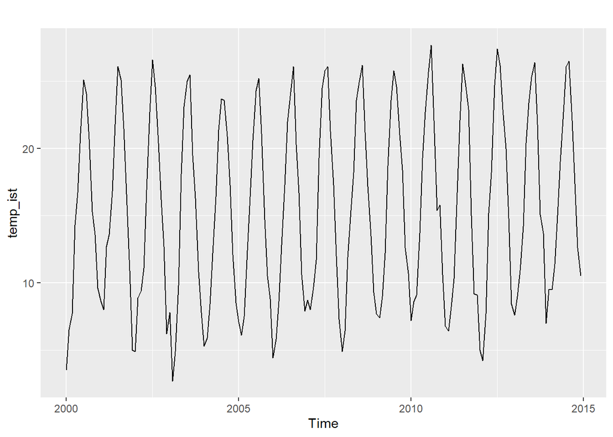

```r
load("Data/weather_istanbul.rda")
temp_ist <- ts(weather_istanbul$temp, start = c(2000,1), frequency = 12)
autoplot(temp_ist)
```

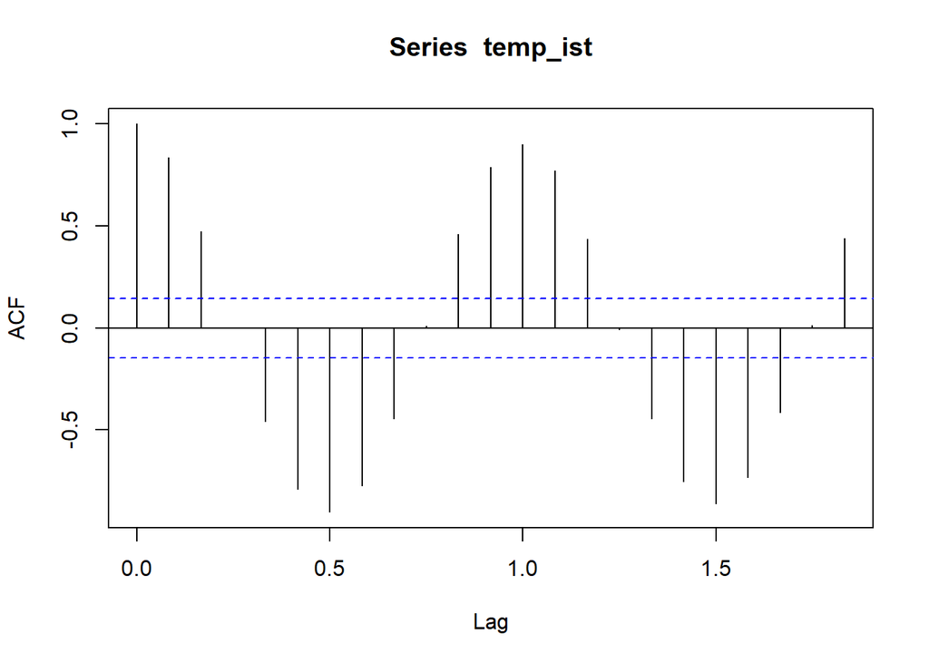

```r
# ACF, base R
acf(temp_ist)
```

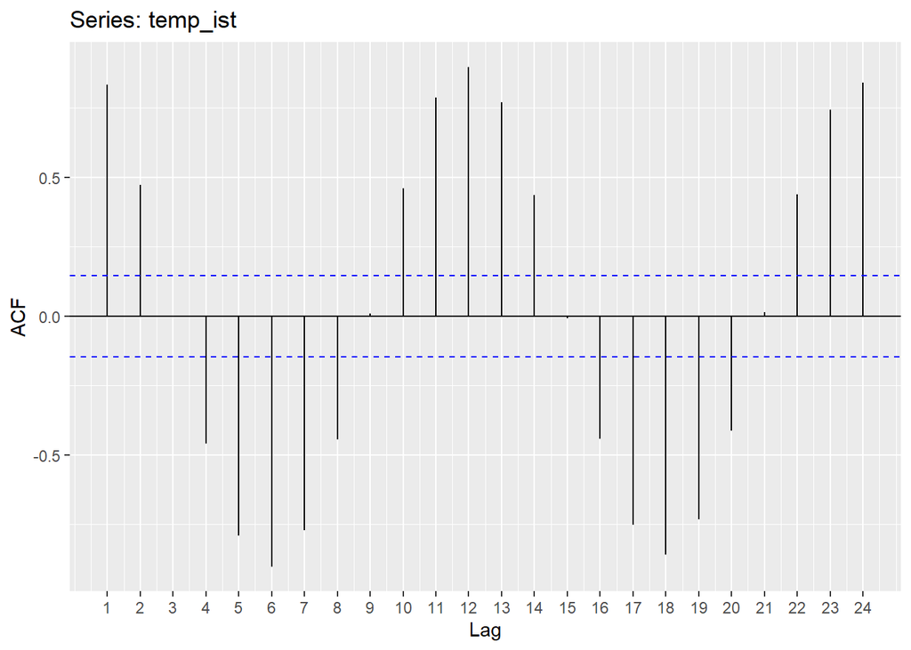

```r
# örneklem ACF
ggAcf(temp_ist,24) + scale_x_continuous(breaks = seq(1,24,1))
```

### 1.3.2 Örnek: Gelen turist sayısı

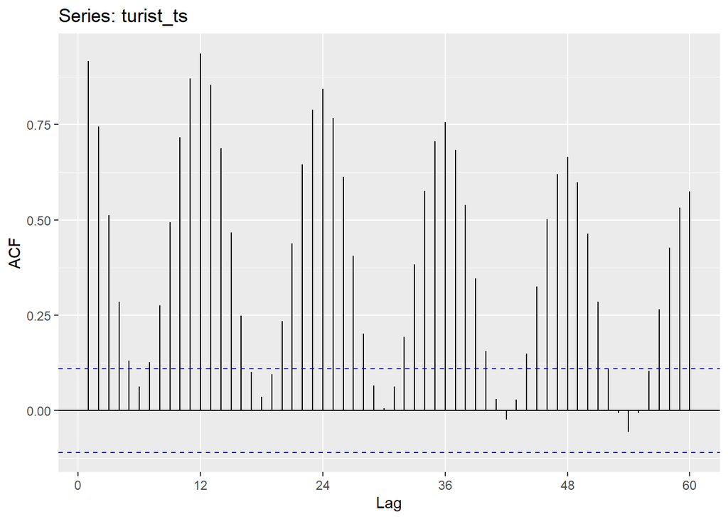

```r
ggAcf(turist_ts, 60)
```

### 1.3.3 Örnek: Türkiye yıllık makroekonomik verileri

```r
# Gerekli paketler
library(tidyverse)
library(fable)   # tools for time series forecasting
library(feasts)  # Feature Extraction And Statistics for Time Series
library(tsibble) # time series tibble object
library(tsibbledata) # for data sets
data("global_economy")
head(global_economy)
```

```
## # A tsibble: 6 x 9 [1Y]
## # Key:       Country [1]
##   Country     Code   Year         GDP Growth   CPI Imports Exports Population
##   <fct>       <fct> <dbl>       <dbl>  <dbl> <dbl>   <dbl>   <dbl>      <dbl>
## 1 Afghanistan AFG    1960  537777811.     NA    NA    7.02    4.13    8996351
## 2 Afghanistan AFG    1961  548888896.     NA    NA    8.10    4.45    9166764
## 3 Afghanistan AFG    1962  546666678.     NA    NA    9.35    4.88    9345868
## 4 Afghanistan AFG    1963  751111191.     NA    NA   16.9     9.17    9533954
## 5 Afghanistan AFG    1964  800000044.     NA    NA   18.1     8.89    9731361
## 6 Afghanistan AFG    1965 1006666638.     NA    NA   21.4    11.3     9938414
```

```r
korea_data <- global_economy %>%
  filter(Code == "KOR")
head(korea_data)
```

```
## # A tsibble: 6 x 9 [1Y]
## # Key:       Country [1]
##   Country     Code   Year         GDP Growth   CPI Imports Exports Population
##   <fct>       <fct> <dbl>       <dbl>  <dbl> <dbl>   <dbl>   <dbl>      <dbl>
## 1 Korea, Rep. KOR    1960 3957873926.  NA     1.48    12.0    2.62   25012374
## 2 Korea, Rep. KOR    1961 2417237754.   6.88  1.60    14.0    4.04   25765673
## 3 Korea, Rep. KOR    1962 2813933900.   3.84  1.70    15.6    3.87   26513030
## 4 Korea, Rep. KOR    1963 3988246109.   9.19  2.06    14.7    3.95   27261747
## 5 Korea, Rep. KOR    1964 3458518494.   9.46  2.66    12.4    4.96   27984155
## 6 Korea, Rep. KOR    1965 3120307808.   7.18  3.02    14.3    7.13   28704674
```

```r
turkey_data <- global_economy %>%
  filter(Country == "Turkey")
head(turkey_data)
```

```
## # A tsibble: 6 x 9 [1Y]
## # Key:       Country [1]
##   Country Code   Year          GDP Growth       CPI Imports Exports Population
##   <fct>   <fct> <dbl>        <dbl>  <dbl>     <dbl>   <dbl>   <dbl>      <dbl>
## 1 Turkey  TUR    1960 13995067818.  NA    0.0000540    3.67    2.06   27472331
## 2 Turkey  TUR    1961  8022222222.   1.16 0.0000557    6.79    5.12   28146893
## 3 Turkey  TUR    1962  8922222222.   5.57 0.0000578    7.97    5.60   28832805
## 4 Turkey  TUR    1963 10355555556.   9.07 0.0000615    6.97    4.18   29531342
## 5 Turkey  TUR    1964 11177777778.   5.46 0.0000622    5.47    4.47   30244232
## 6 Turkey  TUR    1965 11944444444.   2.82 0.0000650    5.40    4.56   30972965
```

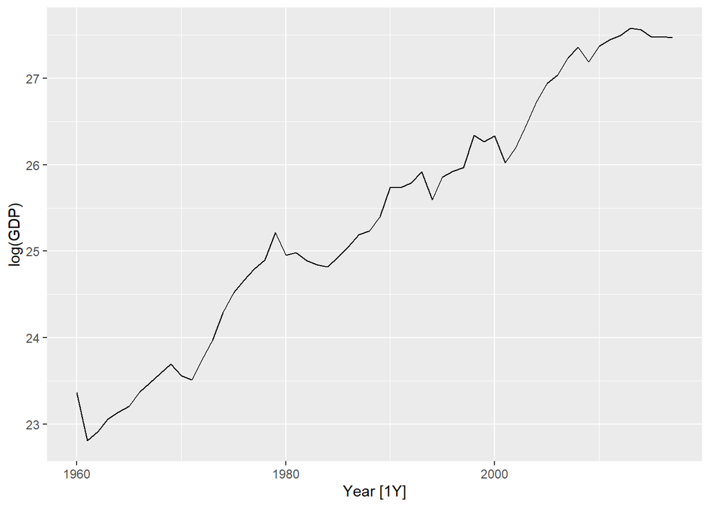

```r
turkey_data %>% autoplot(log(GDP))
```

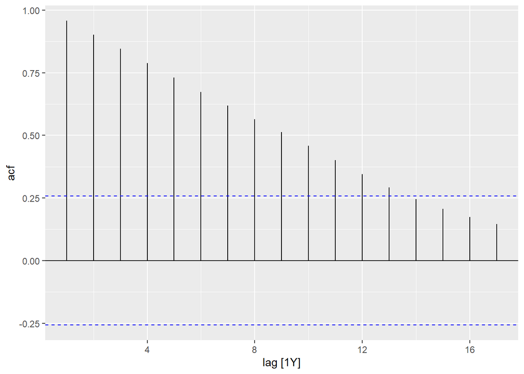

```r
turkey_data %>% ACF(log(GDP)) %>% autoplot()
```

ACF grafiğine göre GDP geçmiş değerlere yüksek derecede bağımlılık sergilemektedir. ACF değerleri gecikme uzunluğu arttıkça azalmaktadır. Zaman içinde düzenli artış sergileyen (pozitif trend) zaman serileri tipik olarak yukarıdaki gibi bir ACF grafiğine sahip olur.

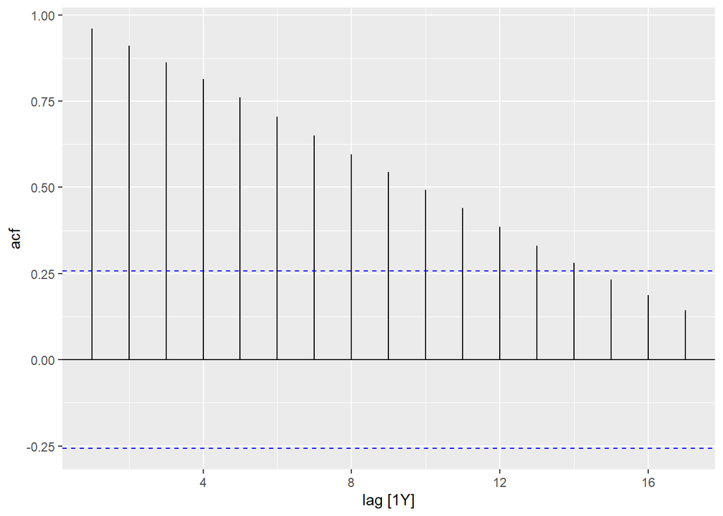

```r
# KORE GDP verileri
korea_data %>% ACF(log(GDP)) %>% autoplot()
```

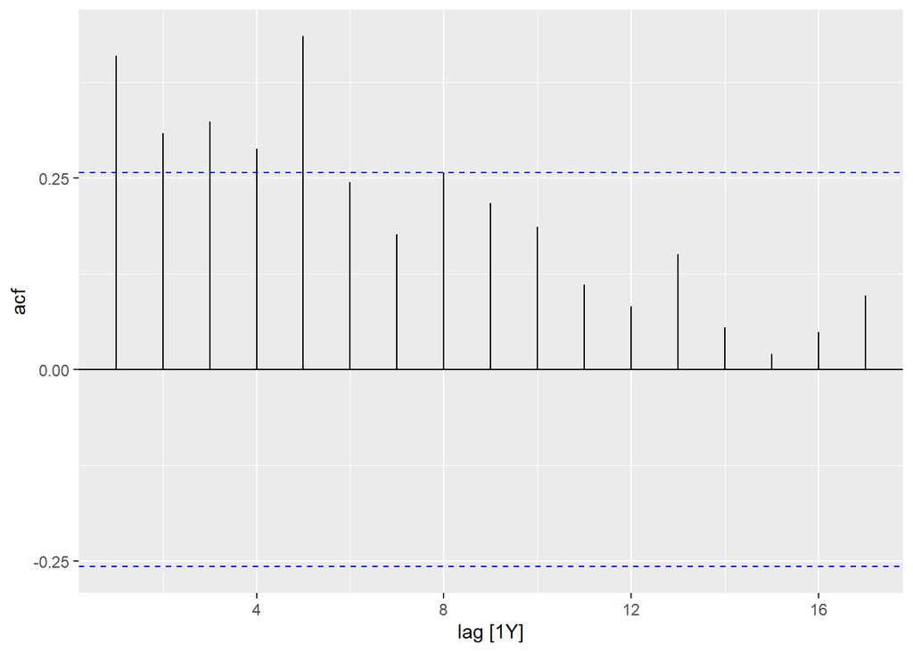

```r
# KORE büyüme oranı
korea_data %>% ACF(Growth) %>% autoplot()
```

Büyüme oranının ACF grafiğine bakalım:

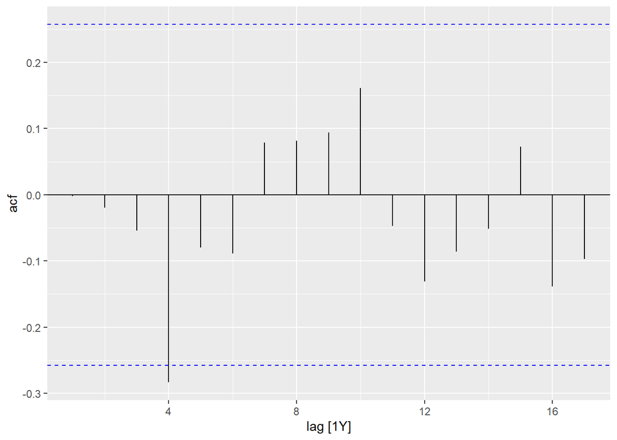

```r
turkey_data %>% ACF(Growth) %>% autoplot()
```

Tüm gecikmelerde ACF değerleri istatistik bakımından sıfırdan farklı değildir (4. gecikme hariç, ancak gözardı edilebilecek kadar küçüktür).

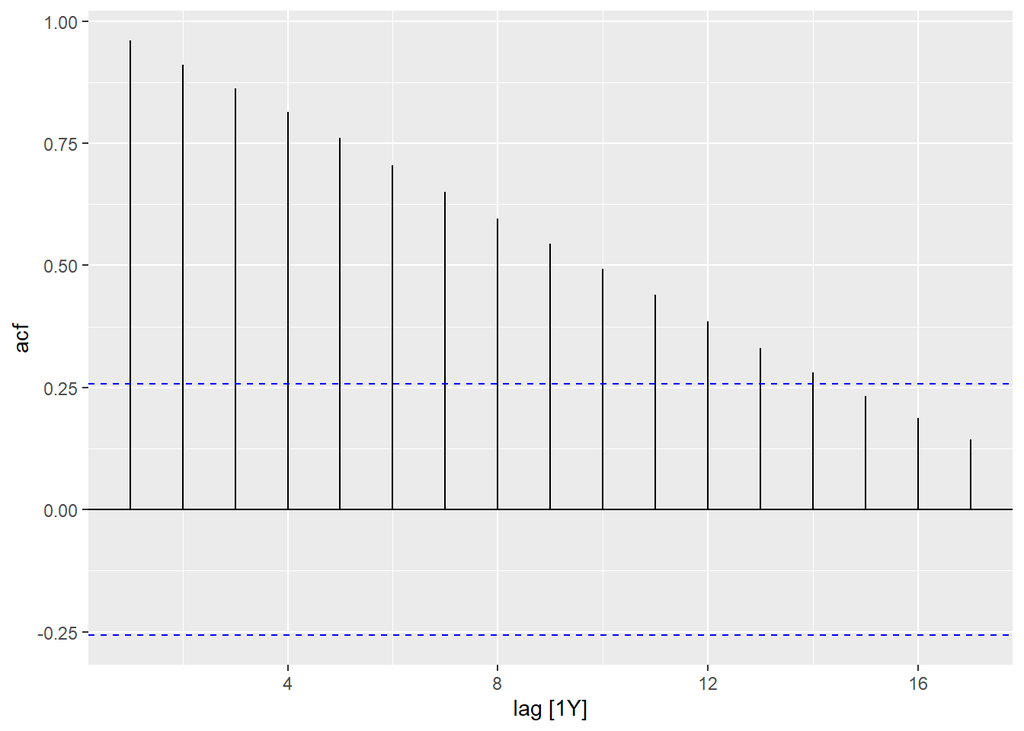

```r
# KORE GDP verileri
korea_data %>% ACF(log(GDP)) %>% autoplot()
```

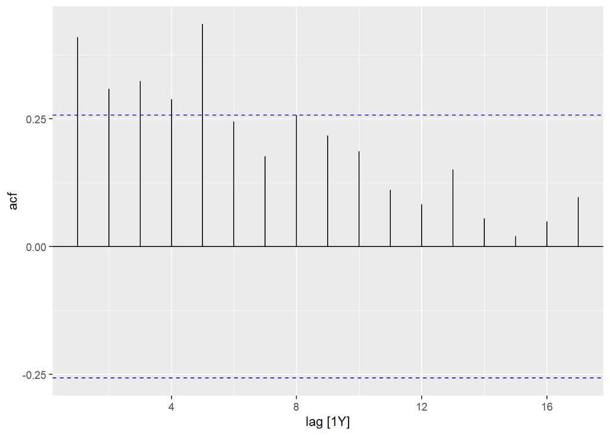

```r
# KORE büyüme oranı
korea_data %>% ACF(Growth) %>% autoplot()
```

### 1.3.4 Örnek: Hisse senedi piyasası

```r
# tsibbledata::gafa_stock
data("gafa_stock")
head(gafa_stock)
```

```
## # A tsibble: 6 x 8 [!]
## # Key:       Symbol [1]
##   Symbol Date        Open  High   Low Close Adj_Close    Volume
##   <chr>  <date>     <dbl> <dbl> <dbl> <dbl>     <dbl>     <dbl>
## 1 AAPL   2014-01-02  79.4  79.6  78.9  79.0      67.0  58671200
## 2 AAPL   2014-01-03  79.0  79.1  77.2  77.3      65.5  98116900
## 3 AAPL   2014-01-06  76.8  78.1  76.2  77.7      65.9 103152700
## 4 AAPL   2014-01-07  77.8  78.0  76.8  77.1      65.4  79302300
## 5 AAPL   2014-01-08  77.0  77.9  77.0  77.6      65.8  64632400
## 6 AAPL   2014-01-09  78.1  78.1  76.5  76.6      65.0  69787200
```

Bu veri setinde Google, Apple, Facebook ve Amazon hisse senetlerinin günlük piyasa bilgileri yer almaktadır. Veri seti `tsibble` formatındadır. `{tsibble}`, `{fable}`, `{feasts}` paketlerine ilişkin daha fazla bilgi için bkz https://tidyverts.org/ ve https://otexts.com/fpp3/tsibbles.html.

Google serisi:

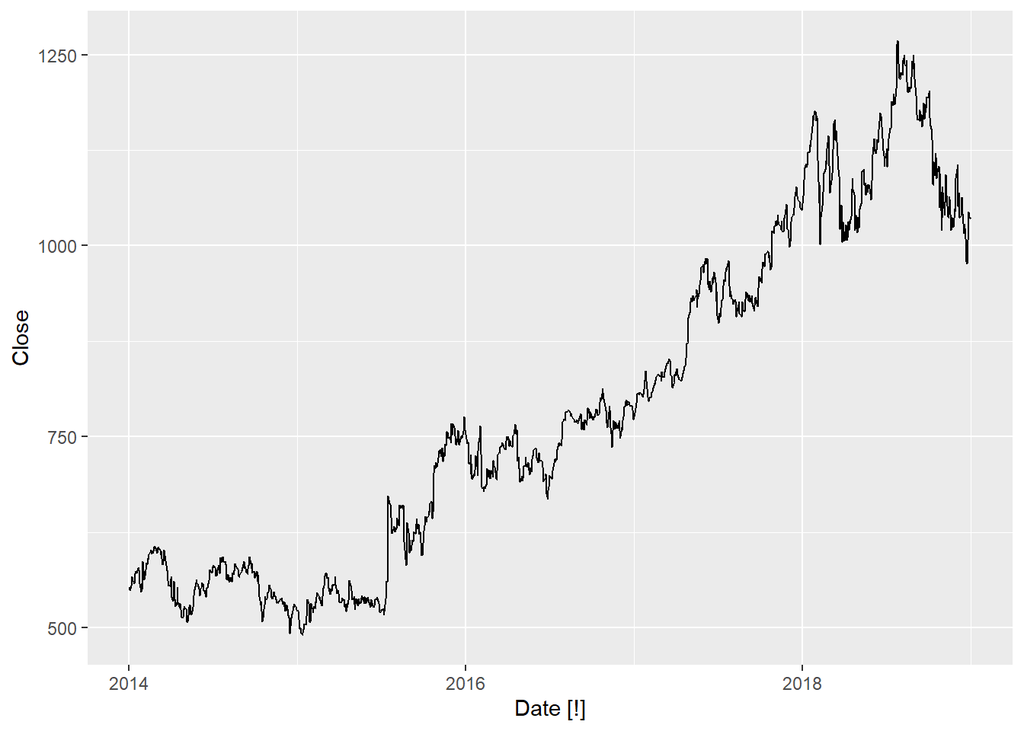

```r
# tsibbledata::gafa_stock
gafa_stock %>% filter(Symbol == "GOOG") %>%
  autoplot(Close)
```

Google ACF grafiği:

```r
# use feasts::ACF function
gafa_stock %>% filter(Symbol == "GOOG") %>%
  ACF(Close, lag_max = 10)
```

```
## # A tsibble: 10 x 3 [1]
## # Key:       Symbol [1]
##    Symbol      lag   acf
##    <chr>  <cf_lag> <dbl>
##  1 GOOG          1 0.997
##  2 GOOG          2 0.995
##  3 GOOG          3 0.992
##  4 GOOG          4 0.990
##  5 GOOG          5 0.988
##  6 GOOG          6 0.985
##  7 GOOG          7 0.983
##  8 GOOG          8 0.981
##  9 GOOG          9 0.979
## 10 GOOG         10 0.978
```

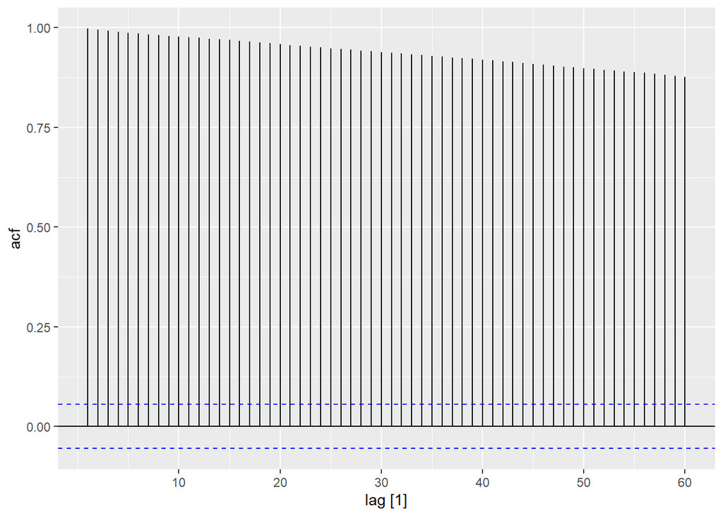

```r
# use feasts::ACF function
gafa_stock %>% filter(Symbol == "GOOG") %>%
  ACF(Close, lag_max = 60) %>%
  autoplot()
```

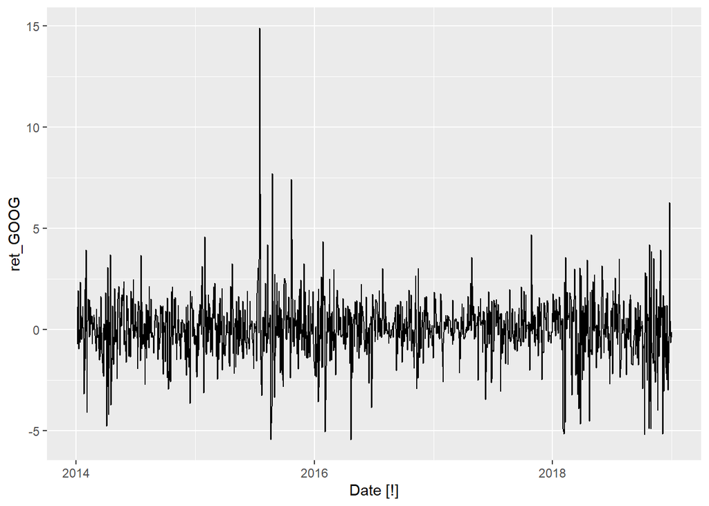

```r
# use feasts::ACF function
gafa_stock %>% filter(Symbol == "GOOG") %>%
  mutate(ret_GOOG = 100*(log(Close) - lag(log(Close)))) %>%
  autoplot(ret_GOOG)
```

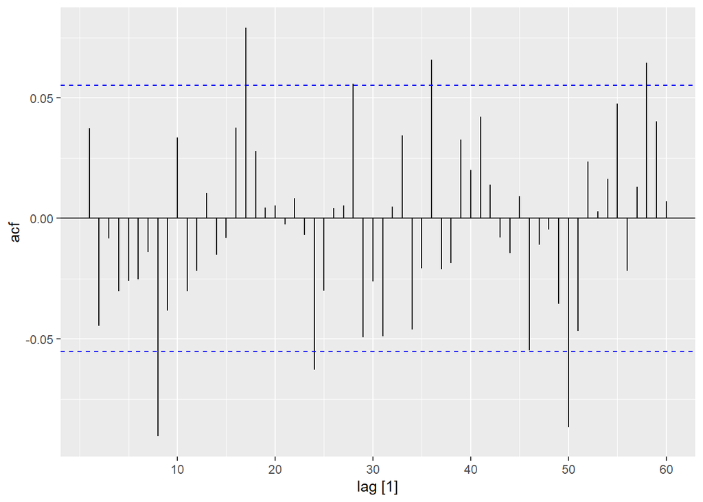

```r
# sadece google hissesinde oluşan veri seti
google <- gafa_stock %>% filter(Symbol == "GOOG") %>%
  mutate(ret_GOOG = 100*(log(Close) - lag(log(Close))))
#
google %>% ACF(ret_GOOG, lag_max = 60) %>%
  autoplot()
```

`{feasts::gg_tsdisplay()}` fonksiyonu:

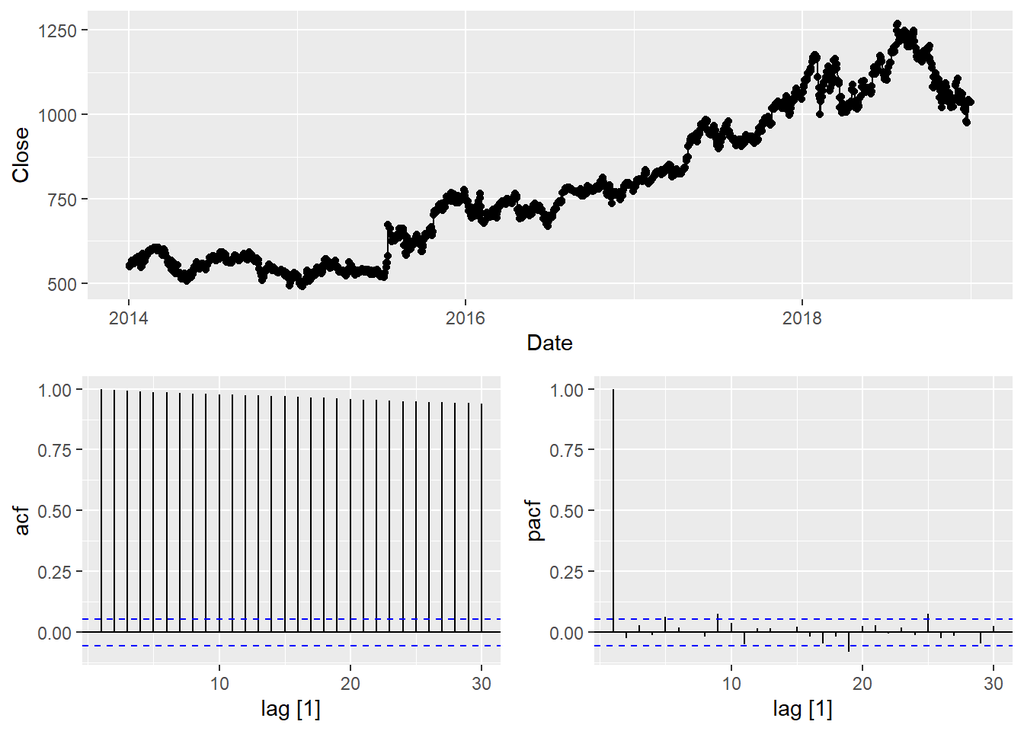

```r
# partial option: Kısmi otokorelasyon fonksiyonu (PACF)
google %>% gg_tsdisplay(Close, plot_type = 'partial')
```

# 2 Klasik zaman serisi ayrıştırması

## 2.1 Trend-çevrim bileşeni için basit bir tahminci

Hareketli ortalama düzleştiricisi ile Trend-Çevrim bileşeni tahmin edilebilir:
$$\hat{Trend}_{t} = \frac{1}{m} \sum_{j=-k}^k
y_{t+j}, \tag{6.1}$$
Burada $m=2k+1$’dir, yani $t$ çevresinde $k$ dönemin verilerinin ortalaması alınır.

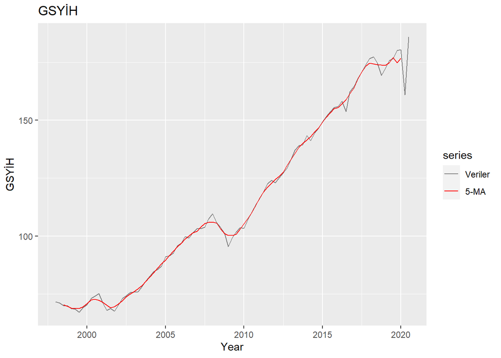

```r
autoplot(gsyih_sa_ts, series="Veriler") +
  autolayer(ma(gsyih_sa_ts, 5), series="5-MA") +
  xlab("Year") + ylab("GSYİH") +
  ggtitle("GSYİH") +
  scale_colour_manual(values=c("Veriler"="grey50","5-MA"="red"),
                      breaks=c("Veriler","5-MA"))
```

Mevsimsel seriler için de benzer şekilde hareketli ortalamalar düzleştiricisi kullanılabilir. Tipik olarak çift sayılı gecikmeler kullanılır. R’da `ma()` fonksiyonu aylık seriler için order=12 ile kullanıldığında merkezi hareketli ortalamalar hesaplanır (günlük veriler için order = 7 alınabilir). Örneğin:

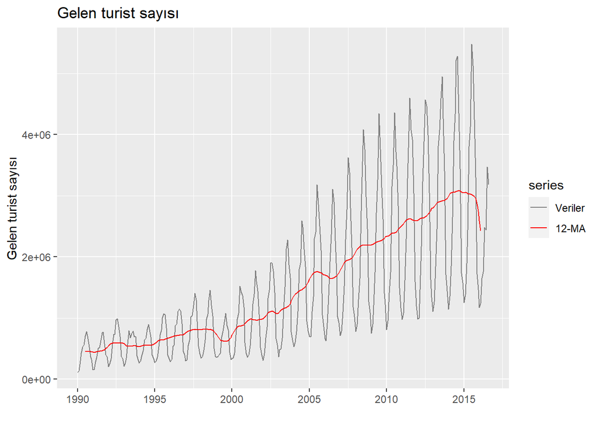

```r
autoplot(turist_ts, series="Veriler") +
  autolayer(ma(turist_ts, order = 12), series="12-MA") +
  xlab("") + ylab("Gelen turist sayısı") +
  ggtitle("Gelen turist sayısı") +
  scale_colour_manual(values=c("Veriler"="grey50","12-MA"="red"),
                      breaks=c("Veriler","12-MA"))
```

Logaritmik dönüştürme ile trend-çevrim:

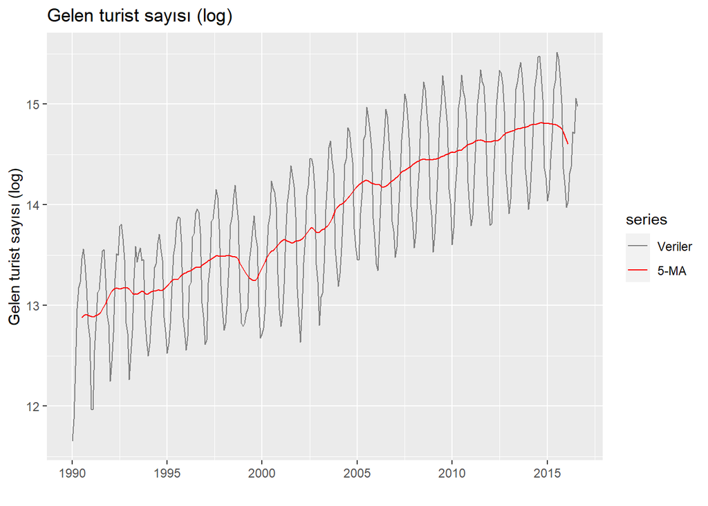

```r
autoplot(log(turist_ts), series="Veriler") +
  autolayer(ma(log(turist_ts), order = 12), series="5-MA") +
  xlab("") + ylab("Gelen turist sayısı (log)") +
  ggtitle("Gelen turist sayısı (log)") +
  scale_colour_manual(values=c("Veriler"="grey50","5-MA"="red"),
                      breaks=c("Veriler","5-MA"))
```

## 2.2 R ile klasik dekompozisyon

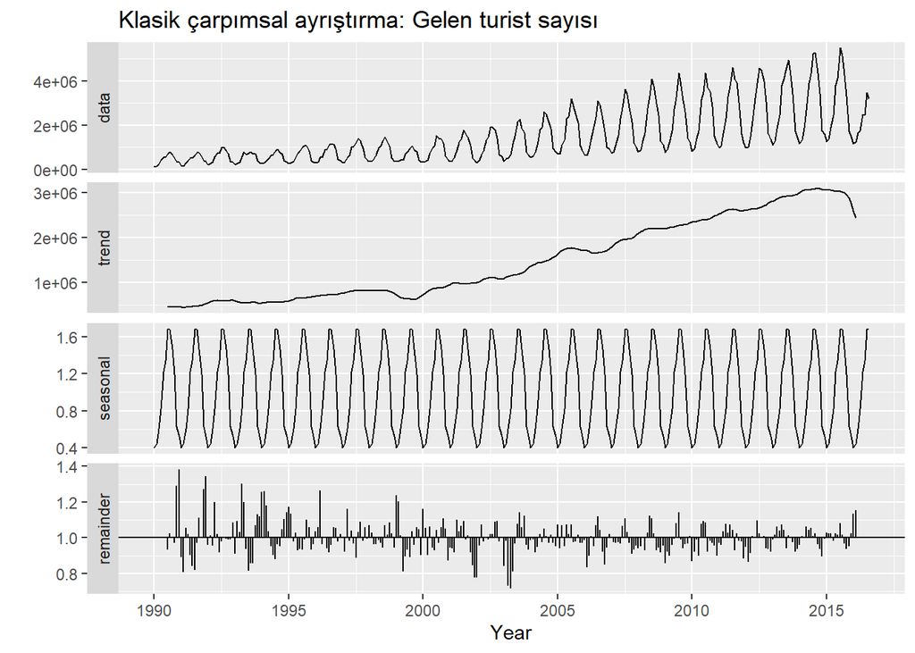

```r
turist_ts %>% decompose(type="multiplicative") %>%
  autoplot() + xlab("Year") +
  ggtitle("Klasik çarpımsal ayrıştırma: Gelen turist sayısı")
```

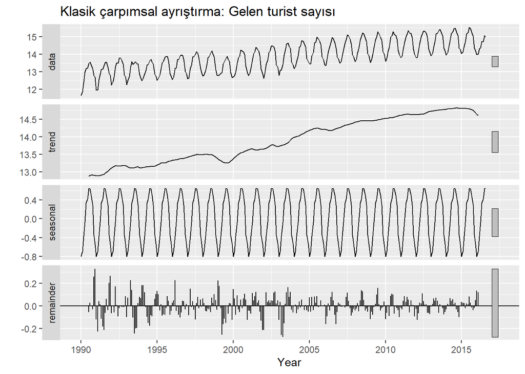

```r
log(turist_ts) %>% decompose(type="additive") %>%
  autoplot() + xlab("Year") +
  ggtitle("Klasik çarpımsal ayrıştırma: Gelen turist sayısı")
```